# NLP Midterm

- Hunter Barclay
- Feb. 16th, 2025

## My Approach

```python
import numpy as np
import pandas as pd
import nltk
```

```python
data = pd.read_csv('pnp-train-2.txt',delimiter='\t',encoding='latin-1', # utf8 encoding didn't work for this
                  names=['type','name'])
data
```

|  | type | name |
| --- | --- | --- |
| 0 | drug | Dilotab |
| 1 | movie | Beastie Boys: Live in Glasgow |
| 2 | person | Michelle Ford-Eriksson |
| 3 | place | Ramsbury |
| 4 | place | Market Bosworth |
| ... | ... | ... |
| 20996 | movie | Old Pals |
| 20997 | place | Mailly-le-Château |
| 20998 | place | Sudbury |
| 20999 | place | West Wickham |
| 21000 | drug | Ocusporin |

21001 rows × 2 columns

```python
test = data.sample(frac=0.05,random_state=100)
train = data.drop(test.index)
```

```python
def Tokenize(phrase=''):
    return nltk.word_tokenize(phrase)

print(Tokenize('Lorem ipsum dolor sit amet'))
```

```
['Lorem', 'ipsum', 'dolor', 'sit', 'amet']
```

```python
# Get token counts
# https://www.geeksforgeeks.org/python-matrix-elements-frequencies-counter/
from collections import Counter
from tqdm import tqdm

all_tokens = [Tokenize(n) for n in train.name]
token_counter = sum(tqdm(map(Counter, all_tokens), total=len(all_tokens)), Counter())
```

```python
ptoken_smooth = 0.00000001
def Ptoken(token=''):
    count = token_counter[token]
    return ptoken_smooth if count == 0 else count / token_counter.total()
```

```python
sum([Ptoken(t) for t in token_counter.keys()])
```

```
1.0
```

```python
type_counter = Counter(train.type)
ptype_smooth = 0.000000001
def Ptype(t=''):
    count = type_counter[t]
    return ptype_smooth if count == 0 else count / type_counter.total()
```

```python
sum([Ptype(t) for t in set(train.type)])
```

```
1.0
```

```python
tokens_per_type = {}
for t in set(train.type):
    tokens_per_type[t] = []
    for name in train.loc[train.type == t].name:
        tokens_per_type[t] += Tokenize(name)
token_counter_per_type = {k: Counter(v) for k, v in tokens_per_type.items()}

ptoken_type_type_smooth = 0.00000000001
ptoken_type_token_smooth = 0.00000001
def Ptoken_type(token='', t=''):
    if t not in token_counter_per_type:
        return ptoken_type_type_smooth
    count = token_counter_per_type[t][token]
    return ptoken_type_token_smooth if count == 0 else count / token_counter_per_type[t].total()
```

```python
Ptoken_type('Market', 'place')
```

```
0.001771703366236396
```

```python
Ptoken_type('Kuuga', 'place')
```

```
1e-08
```

```python
def Guess(name=''):
    tokens = Tokenize(name)
    return max([(t, np.prod([Ptoken_type(token, t) for token in tokens])) for t in type_counter.keys()], key=lambda x: x[1])
```

```python
Guess('Market Hatfield')
```

```
('place', 1.3452569219714472e-06)
```

```python
def Accuracy(df):
    return sum([Guess(row['name'])[0] == row.type for i, row in tqdm(df.iterrows(), total=len(df))]) / len(df)
```

```python
trainAcc = Accuracy(train)
print(f'Training Data Accuracy: {trainAcc*100:.2f}%')
```

```
Training Data Accuracy: 99.17%
```

```python
testAcc = Accuracy(test)
print(f'Testing Data Accuracy: {testAcc*100:.2f}%')
```

```
Testing Data Accuracy: 73.05%
```

# Questions and Answers

### What are the two baselines for this particular task? How did you determine the two baselines?

The baselines for this task are our training set and our testing set. I determined this by breaking the main dataset into two, with the test being the smaller one. In particular, I tried to maximize the training set so I went with a 19:1 ratio.

### What is the accuracy of your classifier?

The accuracy of my classifier on the testing set is 73.05%.

### What kind of normalization did you apply? Why does it make sense to do that for this particular task? How does your accuracy change if you don’t apply that normalization strategy?

I used tokenization for this model. I tried a couple different options, but tokenization (by word/puncuation specifically) was the only one that resulted in significant change. I makes sense because with names you encounter a number of words that aren't seen anywhere else. The work around this, tokenization can take advantage of multiple of the same parts of names. Example being the word Company or Inc appearing in the name of a company.

Without it, the accuracy was dismal when tested against the testing dataset (like 20 something percent). I tried Lemmatization but it added nothing, same with setting all the letters in each token to lower case. I avoided removing stop words considering the use of stop words in some names over other could be a strong indicator of the type of name.

### What modeling approach did you use? I.e., how did you model the probability of a name (a sequence of words)?

I created the following probability distribution:

### $$\Pi_{i=1}^{n}P(\text{token}_i|\text{type})$$

From there, given a name, I got the $P(\text{name}|\text{type})$ for each type and returned the maximum for a guess.

When constructing $P(\text{token}_i|\text{type})$, I tokenized all the names, then made individual counters for each type from there, counting tokens rather than just names. This way I don't get blinded when encountering names that I haven't encountered yet.

### What assumptions does your model make?

The model makes the assumption that each token is independent of each other. I'd imagine this wouldn't be true is at least a few cases in the dataset. This can mostly be seen in the fact that the location of a token within a name makes no impact on the guesses. "Overlook Hotel" and "Hotel Overlook" result in the same probability, yet aren't the same.

### Create a confusion matrix of your model’s predictions/guesses vs. the real types. What do you notice?

**See Confusion Matrix and classification report below**

```
<sklearn.metrics._plot.confusion_matrix.ConfusionMatrixDisplay at 0x1675a1190>
```

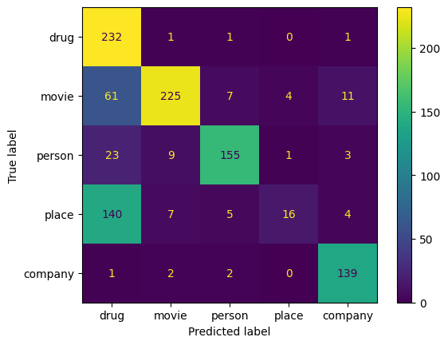

```python
from sklearn.metrics import confusion_matrix, classification_report, ConfusionMatrixDisplay
import seaborn as sns
import matplotlib.pyplot as plt

test_guesses = [(Guess(row['name'])[0], row.type) for i, row in tqdm(test.iterrows(), total=len(test))]
res_df = pd.DataFrame(test_guesses, columns=['pred', 'true'])
mat = confusion_matrix(res_df.true, res_df.pred, labels=list(type_counter.keys()))
disp = ConfusionMatrixDisplay(confusion_matrix=mat, display_labels=type_counter.keys())
disp.plot()
```

```python
print(classification_report(res_df.true, res_df.pred, zero_division=0.0))
```

```
              precision    recall  f1-score   support

     company       0.88      0.97      0.92       144
        drug       0.51      0.99      0.67       235
       movie       0.92      0.73      0.82       308
      person       0.91      0.81      0.86       191
       place       0.76      0.09      0.17       172

    accuracy                           0.73      1050
   macro avg       0.80      0.72      0.69      1050
weighted avg       0.80      0.73      0.70      1050
```